# Analysis with COVID-19 situation in Canada

## Data Visualization

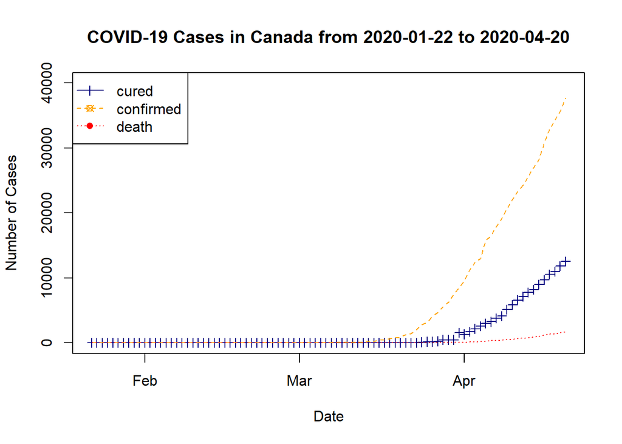

```r
date_for_xaxis <-  c("2020-02-01", "2020-03-01", "2020-04-01")
date_for_xaxis <- as.Date(date_for_xaxis, "%Y-%m-%d")
plot(t_Canada_consolidate$date, t_Canada_consolidate$cured,  main = "COVID-19 Cases in Canada from 2020-01-22 to 2020-04-20", xlab = "Date", ylab = "Number of Cases", ylim = c(0, 40000), xaxt = "n", col = "navyblue", lty = 1, pch = 3)
axis(1, at = t_Canada_consolidate$date[which(t_Canada_consolidate$date %in% date_for_xaxis)], labels = c("Feb", "Mar", "Apr"))
lines(t_Canada_consolidate$date, t_Canada_consolidate$confirmed,  col = "orange", lty = 2, pch = 13)
lines(t_Canada_consolidate$date, t_Canada_consolidate$death,  col = "red", lty = 3, pch = 16)
legend("topleft", col = c("navyblue", "orange", "red"),
       legend = c("cured", "confirmed", "death"),
       pch  = c(3, 13, 16), lty = c(1, 2, 3))
```

```r
                                        # Below is the visualization done by ggplot, only for pratice purpose
reshaped_consolidate_data <- melt(t_Canada_consolidate, id.vars="date")

head(reshaped_consolidate_data,3)
```

```
##         date  variable value
## 1 2020-01-22 confirmed     0
## 2 2020-01-23 confirmed     0
## 3 2020-01-24 confirmed     0
```

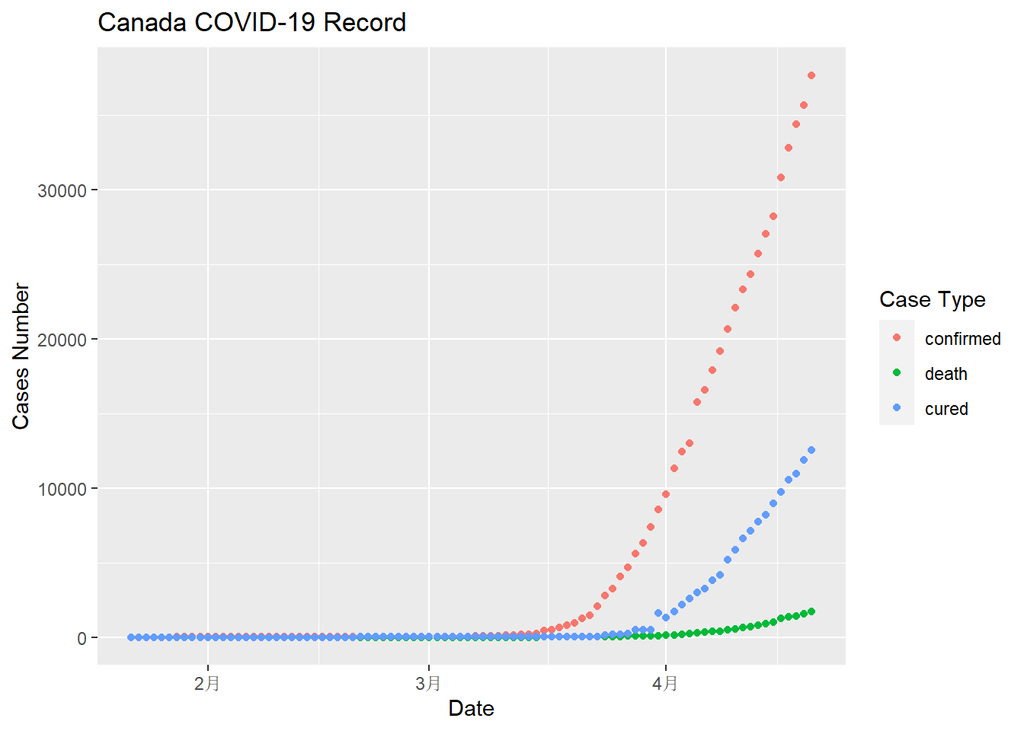

```r
p1 <- ggplot(reshaped_consolidate_data, aes(date, value, col=variable)) +
    geom_point() +  ggtitle("Canada COVID-19 Record") + labs(y = "Cases Number", x = "Date", color = "Case Type")

p1
```

You may be confused with the x-axis labels on my ggplot output. That is Chinese characters. Unfortunately, my laptop has come with the initial configuration of Chinese character which followed by ggplot. I have tried numerous ways to change it to English characters but failed all the time. **If you know anything about a feasible solution, please don’t hesitate to contact me**

## Statistical Inference

The assessment of COVID-19 transimision ability will be the focus of the remaining report.

### SIR Model

To find the transmission ability of COVID-19, we will utilize the SIR model for epidemic. This model simplifies complex situation of a epidemic (pandemic in this case) into a single system where individuals can only have three states (considered as function of time t):

1. Susceptible: not infected yet and not immune, denoted by S
2. Infected: infected and can infect others, denote by I
3. Removed: immuned to the disease or cannot infect others, denote by R

#### Futher Rate Assumption

In this model, we assume further there are 3 more quantities:

1. $\lambda$ is the uniform probability of being infected, note that it is not constant. It must consider other factors like the spreadness of the virus. E.g. if everyone around you has been infected, then there is a larger change that you get infected than an average person.
2. $\mu$ is the uniform probability of being dead. This is a very small quantity since it is the natural death rate of the whole world population. We ignore this quantity.
3. $\gamma$ is the uniform probability of being recovered

Based on the model assumption and the further rate assumption, we were able to obtain the following system of Diffferential Equations

$$\begin{aligned}
\frac{dS}{dt} &= B - \lambda S - \mu S\\
\frac{dI}{dt} &= \lambda S - \gamma I - \mu I\\
\frac{dR}{dt} &= \gamma I - \mu R
\end{aligned}$$
where $B$ is the bith rate of the population

#### Relationship between each assumed varible

By solving the system of differential equation, we were able to obtain
$$I(t) = I_{0}e^{(R_{0} - 1)(\gamma + \mu)t} \approx I_{0}e^{(R_{0}
- 1) \gamma t}$$
Where $I_{0}$ is the intial amount of people getting infected. Note that clearly not every quantity is constant otherwise $I(t)$ will never decrease. This is a model for early stage

**$R_{0}$** is usually what we call **reproduction number**.

#### Estimation of $\gamma$

From the given fomula above, we have observation for $I(t)$ at different time point t, from january 2020 to April 2020

With our assumption, $1/\gamma$ is the rate of recovery of the infected population **over a period**. Hence, $\gamma$ is the average time length of the period to get one recovered. We can model this process using a Poisson ditribution with $Y_i \sim Poi(1/\gamma)$ and we need to estimate $\gamma$. In this case, $Y_i$ is the number of recovered people over a fixed period of time.

As $1/\gamma$ is dealing with recovery cases, then our sample in this case would be

```r
recover_sample <- t_Canada_consolidate$cured
recover_sample <- diff(recover_sample, lag = 1)
# This is to get the data fro difference between any two days since cured is the total cases and we want each days' recovery data.
```

Now we perform **Maximum Likelihood Method** and get

$$\begin{equation}
\begin{aligned}
L(\theta) &=
\Pi_{i=1}^{n}\frac{e^{(-\theta)}\theta^{y_{i}}}{y_{i}!}\\
&=
(\Pi_{i=1}^{n}\frac{1}{y_{i}!})e^{-n\theta}\theta^{\sum_{i=1}^{n}y_{i}}\\
&=Ce^{-n\theta}\theta^{\sum_{i=1}^{n}y_{i}}
\end{aligned}
\end{equation}$$
where the C is standing for the proportionality.

We write this function in R

```r
poiLF <- function(theta) {exp(-length(recover_sample) * theta) * theta ^ sum(recover_sample)}
```

We can directly graph poiLF to find out which theta maximizes this function, however,

```r
sum(recover_sample)
```

```
## [1] 12543
```

The value is too big, it’s going to be very difficult to visualize the likelihood function on this data and find out the point that maximizes the function. Hence, we use the loglikelihood function.

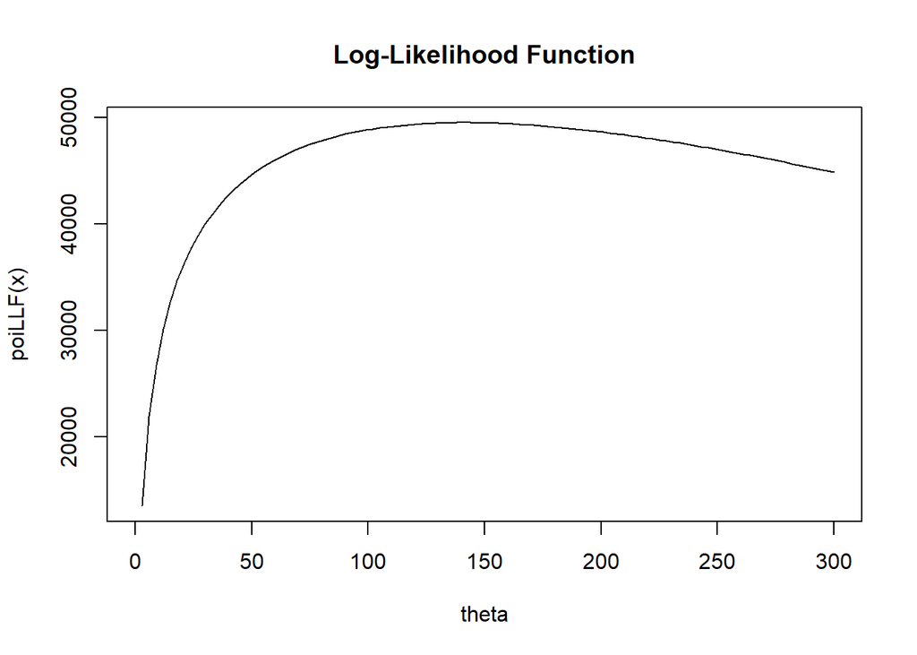

```r
poiLLF <- function(theta) {
    -length(recover_sample) * theta+sum(recover_sample) * log(theta)
}

curve(poiLLF, xlim = c(0, 300), xlab = "theta", main = "Log-Likelihood Function")
```

From the graph, we can roughly get that the theta that maximizes the function is get around 150.

```r
mle_result <- optimize(poiLLF, interval = c(0, 300),maximum = TRUE)
mle_result
```

```
## $maximum
## [1] 140.9326
##
## $objective
## [1] 49523.3
```

```r
gamma_mle <- 1/mle_result$maximum
```

#### Estimation of $R_0$

$$I(t) = I_{0}e^{(R_{0} - 1)(\gamma + \mu)t} \approx I_{0}e^{(R_{0}
- 1) \gamma t}$$

The relationship of $R_0$ in this original equation may be a bit hard to model. However, if we take a log at both sides of equation, we get

$$log I = log I_0 + (R_0 - 1) \gamma t$$

It demonstrates a linear relationship between log I and the time t. Hence, we can apply simple lienar regression for modelling

As before, we need data for I, the confirmed_sample, but we do not need daily new increase.

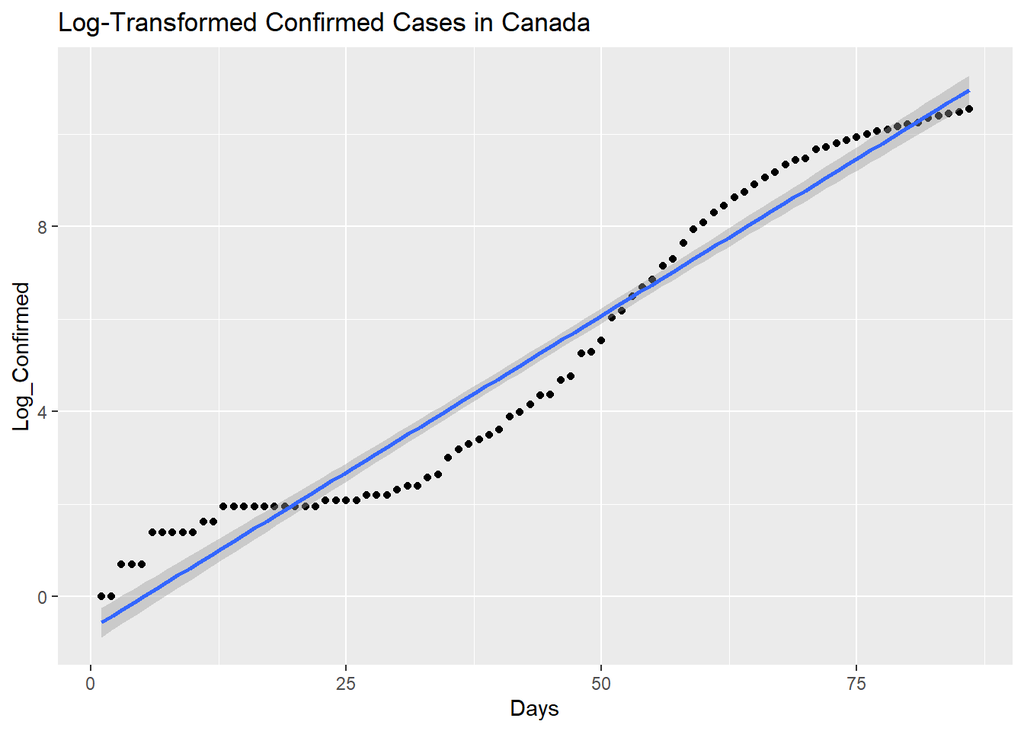

```r
# log is not defined for log(0), hence, we remove the points where the confirmed cases are of 0

confirmed_sample <- t_Canada_consolidate$confirmed[t_Canada_consolidate$confirmed != 0]
log_confirmed_sample <- log(confirmed_sample)
logconfirmed_df <- data.frame(Days = 1:length(log_confirmed_sample),
                              Log_Confirmed = log_confirmed_sample)

ggplot(logconfirmed_df, aes(x = Days, y = Log_Confirmed)) + geom_point() + geom_smooth(method = "lm") + ggtitle("Log-Transformed Confirmed Cases in Canada")
```

```r
log_lm <- lm(Log_Confirmed ~ Days, data = logconfirmed_df)
summary(log_lm)
```

```
##
## Call:
## lm(formula = Log_Confirmed ~ Days, data = logconfirmed_df)
##
## Residuals:
##      Min       1Q   Median       3Q      Max
## -1.26988 -0.72236  0.08198  0.68290  1.27204
##
## Coefficients:
##              Estimate Std. Error t value Pr(>|t|)
## (Intercept) -0.698895   0.160658   -4.35  3.8e-05 ***
## Days         0.135525   0.003208   42.25  < 2e-16 ***
## ---
## Signif. codes:  0 '***' 0.001 '**' 0.01 '*' 0.05 '.' 0.1 ' ' 1
##
## Residual standard error: 0.7385 on 84 degrees of freedom
## Multiple R-squared:  0.9551, Adjusted R-squared:  0.9545
## F-statistic:  1785 on 1 and 84 DF,  p-value: < 2.2e-16
```

The reason for such a high value of the estimate is mainly attribute to the lack of sufficient data. Reproductive number represent how many people will be infected by any one infected people. From our graph, we can see that the values of the confirmed cases skyrocketed to at the end of our data collection periods. Before that, the cases are leveled around 0. This dramatic, sudden increase is what causes the large estimate of the reproductive number.

This reproductive number can only be used as an indication of the severity of COVID-19 not for an accurate estimate of the infectious ability of COVID-19 as it is too subjective. We have not factored in many other important effects like government newly posed regulation.

To accurately estimate the reproductive number after the a new policy come out. It is recommendated to estimate the reproductive number by periods, e.g. weekly, monthly, yearly, etc for the observation of possible improvment.